# MDS example: Morse code

Pedro Delicado

20/feb./2022

## Introduction

The purpose of this example is to learn to apply multidimensional scaling (MDS) in R. The data set we will use in this practical refers to Morse code. There are 36 symbols in the standard version of Morse code.  
Each Morse code symbol represents a text character (26 letters plus 10 numeral) and is represented by a unique sequence of dots and dashes.

### Reading the data

Runs the following R instructions:

```r
#install.packages("xgobi")
library(xgobi)
data(morsecodes)
# ?morsecodes

morsecodes.row
```

```
##       [,1] [,2]
##  [1,] "A"  ".-"
##  [2,] "B"  "-..."
##  [3,] "C"  "-.-."
##  [4,] "D"  "-.."
##  [5,] "E"  "."
##  [6,] "F"  "..-."
##  [7,] "G"  "--."
##  [8,] "H"  "...."
##  [9,] "I"  ".."
## [10,] "J"  ".---"
## [11,] "K"  "-.-"
## [12,] "L"  ".-.."
## [13,] "M"  "--"
## [14,] "N"  "-."
```

[output cut: 22 more lines]

They allow you to have the Morse code (`morsecode.row`) as well as a distance matrix (`morsecodes.dist`) between symbols coming from the confusion rates observed by exposing subjects to pairs of Morse codes (Rothkopf 1957; for more information you can see [here](https://rdrr.io/cran/fechner/man/morse.html)).

Instead of basing MDS on `morsecodes.dist` distance matrix, we use here the R function `adist` to compute the approximate string distance between the character vectors representing the 36 Morse codes (`morsecodes.row[,2]`). The distance computed by `adist` is a *generalized Levenshtein distance* (also known as *edit distance*, and related to *Hamming distance*), giving the minimal possibly weighted number of insertions, deletions and substitutions needed to transform one string into another. You can read the R help page for `adist`.

### Working with Morse codes

1. Computing the edit distance matrix between Morse code symbols using `adist`.

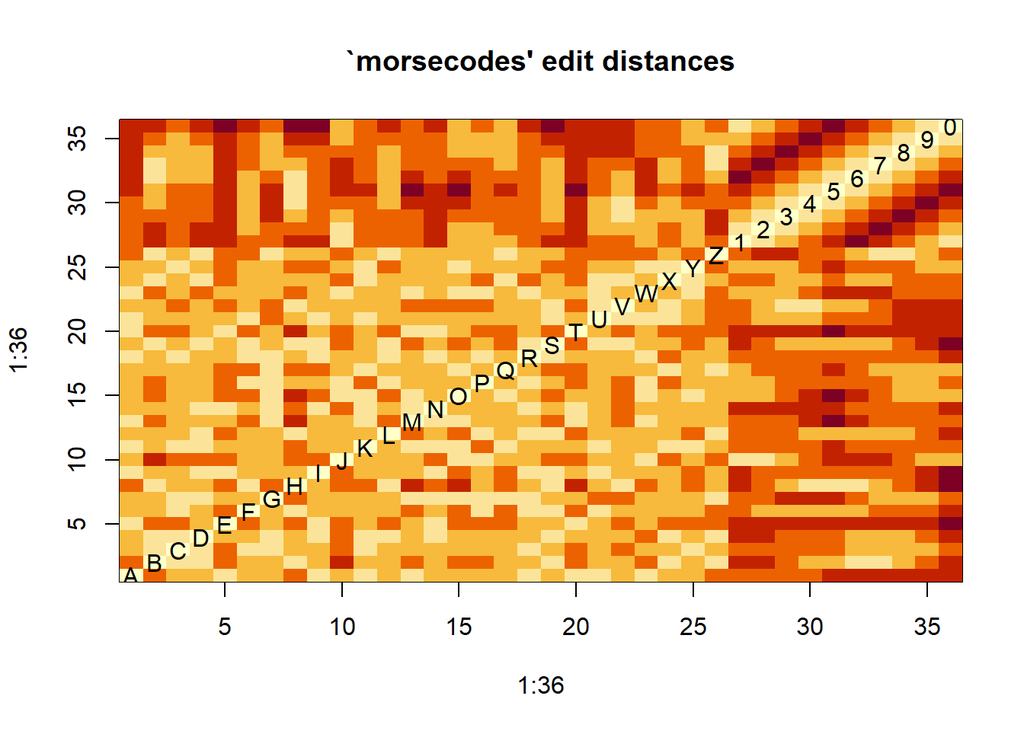

```r
# computing the generalized Levenshtein (edit) distance between letters morse code
ad.mc <- adist(morsecodes.row[,2])
image(1:36, 1:36, ad.mc, main="`morsecodes' edit distances")
text(1:36,1:36, morsecodes.row[,1])
```

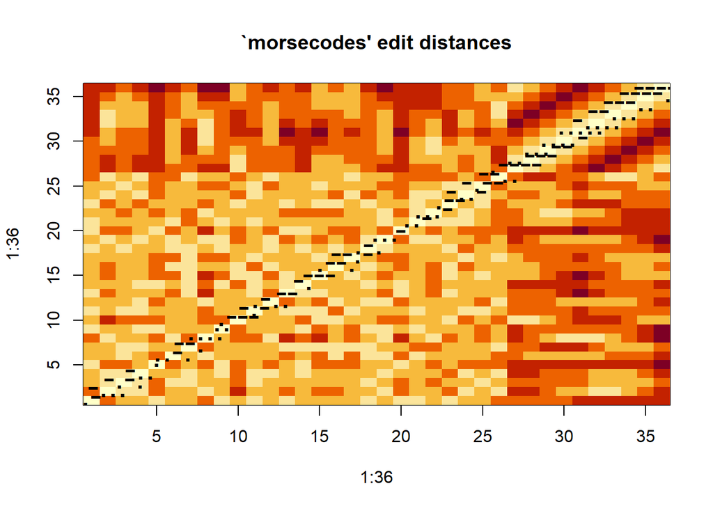

```r
image(1:36, 1:36, ad.mc, main="`morsecodes' edit distances")
text(1:36,1:36, morsecodes.row[,2],cex=2)
```

2. Performing a metric MDS of the data, using the `cmdscale` program.

```r
out <- cmdscale(ad.mc,k=6,eig=TRUE)
out$eig
```

```
##  [1]  51.2939278  40.2995024  39.4961438  16.3192267   9.0878388   4.7629256
##  [7]   4.1721153   3.9757283   3.3974449   3.1903438   2.3840546   2.2393176
## [13]   1.9369434   1.4387754   1.1306946   0.7929050   0.6661905   0.4061370
## [19]   0.0000000  -0.1576399  -0.3838794  -1.0420121  -1.4757580  -1.6622253
## [25]  -2.3027305  -2.6598859  -2.8455611  -3.1957601  -3.4997719  -4.1007708
## [31]  -4.2513032  -4.4043588  -5.0718463  -5.7886098  -9.5923854 -12.3612725
```

What is the value of the elements in `out$GOF`? What is their meaning?

```r
out$GOF
```

```
## [1] 0.6404628 0.8623957
```

```r
print(cumsum(pmax(out$eig,0))/sum(abs(out$eig)))
```

```
##  [1] 0.2037203 0.3637749 0.5206389 0.5854528 0.6215463 0.6404628 0.6570329
##  [8] 0.6728230 0.6863164 0.6989873 0.7084558 0.7173496 0.7250424 0.7307567
## [15] 0.7352474 0.7383965 0.7410423 0.7426554 0.7426554 0.7426554 0.7426554
## [22] 0.7426554 0.7426554 0.7426554 0.7426554 0.7426554 0.7426554 0.7426554
## [29] 0.7426554 0.7426554 0.7426554 0.7426554 0.7426554 0.7426554 0.7426554
## [36] 0.7426554
```

```r
print(cumsum(pmax(out$eig,0))/sum(pmax(out$eig,0)))
```

```
##  [1] 0.2743134 0.4898301 0.7010504 0.7883236 0.8369242 0.8623957 0.8847077
##  [8] 0.9059694 0.9241385 0.9412000 0.9539497 0.9659252 0.9762838 0.9839782
## [15] 0.9900250 0.9942653 0.9978280 1.0000000 1.0000000 1.0000000 1.0000000
## [22] 1.0000000 1.0000000 1.0000000 1.0000000 1.0000000 1.0000000 1.0000000
## [29] 1.0000000 1.0000000 1.0000000 1.0000000 1.0000000 1.0000000 1.0000000
## [36] 1.0000000
```

3. Calcualting the goodness-of-fit (in percentage) of the three-dimensional solution:

```r
cumsum(out$eig[1:3])/sum(pmax(out$eig,0))*100
```

```
## [1] 27.43134 48.98301 70.10504
```

```r
cumsum(out$eig[1:3])/sum(abs(out$eig))*100
```

```
## [1] 20.37203 36.37749 52.06389
```

4. Representing the first 3 dimensions obtained by MDS:

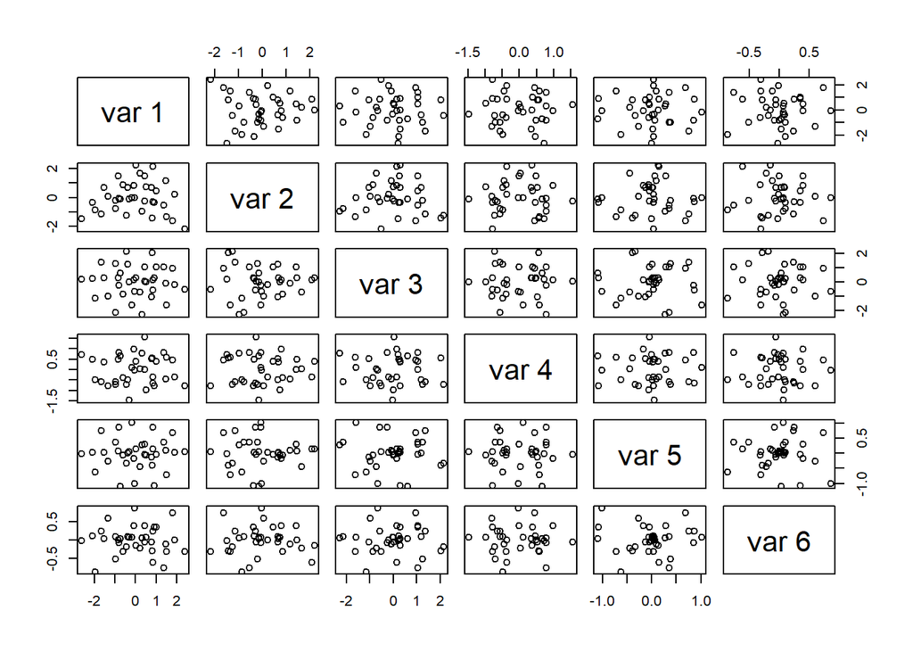

```r
pairs(out$points)
```

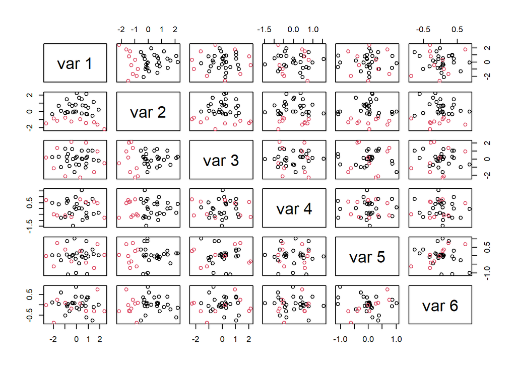

```r
pairs(out$points,col=1+((1:36)>26))
```

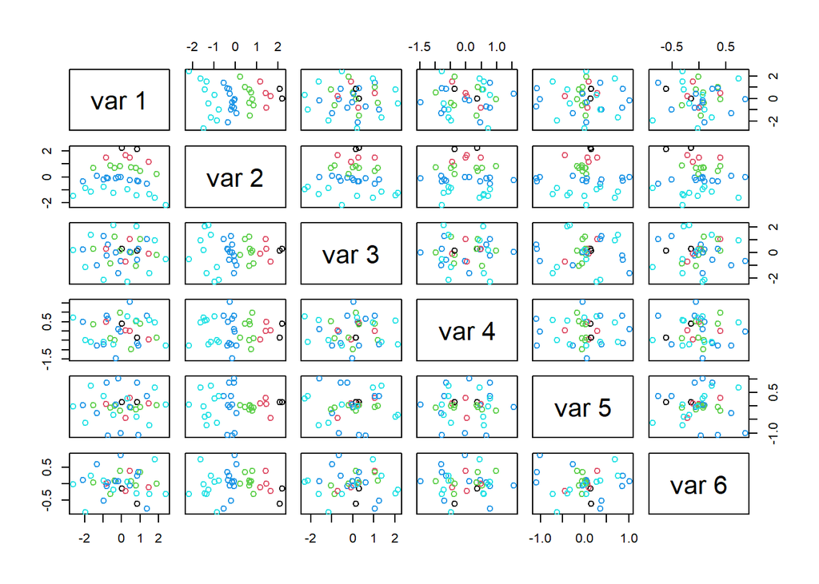

```r
pairs(out$points,col=nchar(morsecodes.row[,2]))
```

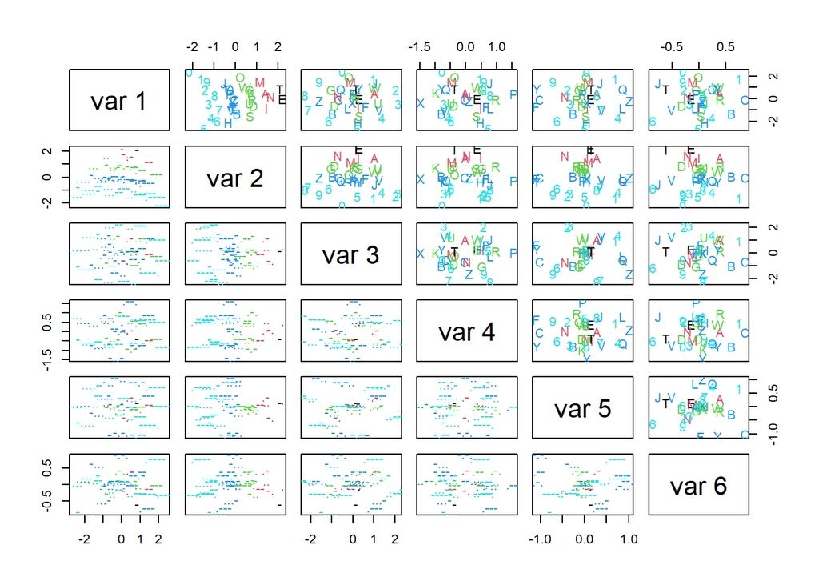

```r
pairs(out$points,
      upper.panel=function(x,y,...){text(x,y,morsecodes.row[,1],...)},
      lower.panel=function(x,y,...){text(x,y,morsecodes.row[,2],...)},
      col=nchar(morsecodes.row[,2])
)
```

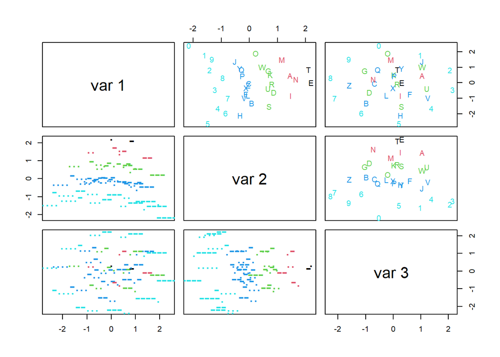

```r
pairs(out$points[,1:3],
      upper.panel=function(x,y,...){text(x,y,morsecodes.row[,1],...)},
      lower.panel=function(x,y,...){text(x,y,morsecodes.row[,2],cex=2,...)},
      col=nchar(morsecodes.row[,2])
)
```

```r
library(rgl)
text3d(out$points[,1:3],texts=morsecodes.row[,1],col=nchar(morsecodes.row[,2]),cex=2)
```

5. Trying to give an *interpretation* to each of the first 3 dimensions.
- 1st dim: (number of ‘-’) - (number of ‘.’)
- 2nd dim: length of the symbols
- 3rd dim: [(number of initials ‘.’) - (number of finals ‘.’)] - [ (number of initials ‘-’) - (number of finals ‘-’) ]
6. Is it possible to find a configuration of the 36 objects in $k$ dimensions that will represent the original distance matrix exactly? Why or why not? If so, how many dimensions would be needed to obtain this exact representation?

*No, because there are some negative eigenvalues. So `ad.mc` is not an Euclidean distance matrix.*

7. Are there any zero eigenvalues? Can you explain these?

*Yes, because the mean of the rows of X is 0.*

8. Compute the fitted distances according to the three-dimensional MDS solution. Graph fitted and observed distances and assess the goodness of fit by regression. Report the coefficient of determination of this regression.

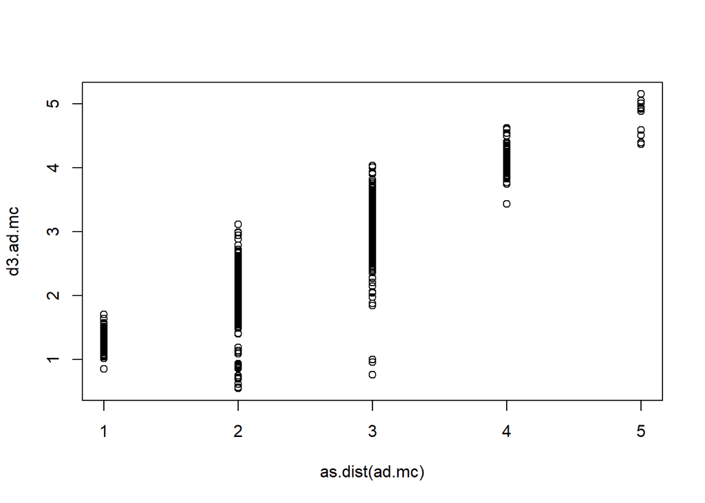

```r
d3.ad.mc <- dist(out$points[,1:3])

plot(as.dist(ad.mc),d3.ad.mc)
```

```r
R2d <- cor(as.dist(ad.mc),d3.ad.mc)^2
# R2d
# [1] 0.820702
```

9. Now we perform **non-metric MDS** with the `isoMDS` program. Plot the three-dimensional solution, labeling the points again with both, the Morse codes and the alphanumeric characters.

```r
library(MASS)
n <- nrow(morsecodes.row)
k <- 3

# initial configuration: cmdscale
out.iso <- isoMDS(ad.mc, k=k)
# initial configuration: random uniform
ini.config <- matrix(runif(k*n),ncol=k)
out.iso <- isoMDS(ad.mc, y=ini.config, k=k)
```

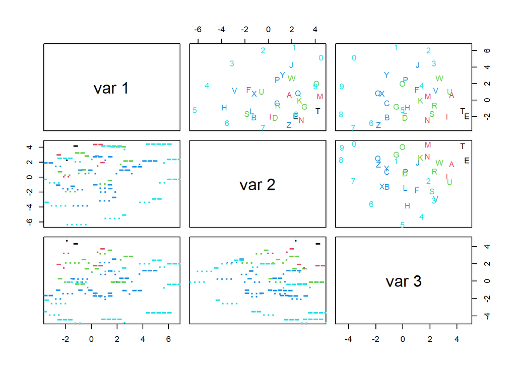

```r
pairs(out.iso$points[,1:3],
      upper.panel=function(x,y,...){text(x,y,morsecodes.row[,1],...)},
      lower.panel=function(x,y,...){text(x,y,morsecodes.row[,2],cex=2,...)},
      col=nchar(morsecodes.row[,2])
)
```

10. Give an *interpretation* to each of the first 3 dimensions and compare them to those obtained by metric scaling.
11. Compute the stress for a 1, 2, 3, 4, 5 and 6 dimensional solution. Plot stress as a function of the dimension. How many dimensions do you think are necessary to obtain a “good fit”?

```r
k<-6
stress <- numeric(k)
dimens <- 1:k
for (i in dimens){
  stress[i] <- isoMDS(ad.mc, k=i)$stress
}
```

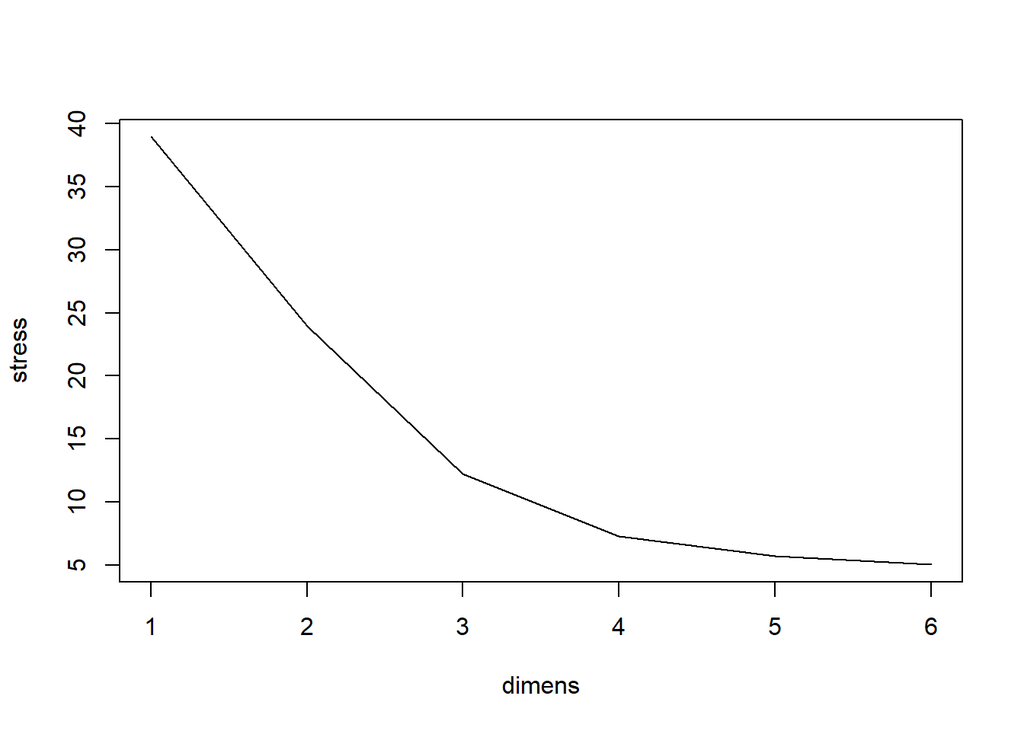

```r
plot(dimens, stress, type="l")
```

12. Make a scatterplot matrix of the first three dimensions of the metric MDS solution and the non-metric MDS solution (use $k=3$). Calculate the correlation matrix of these six variables and comment on your results.

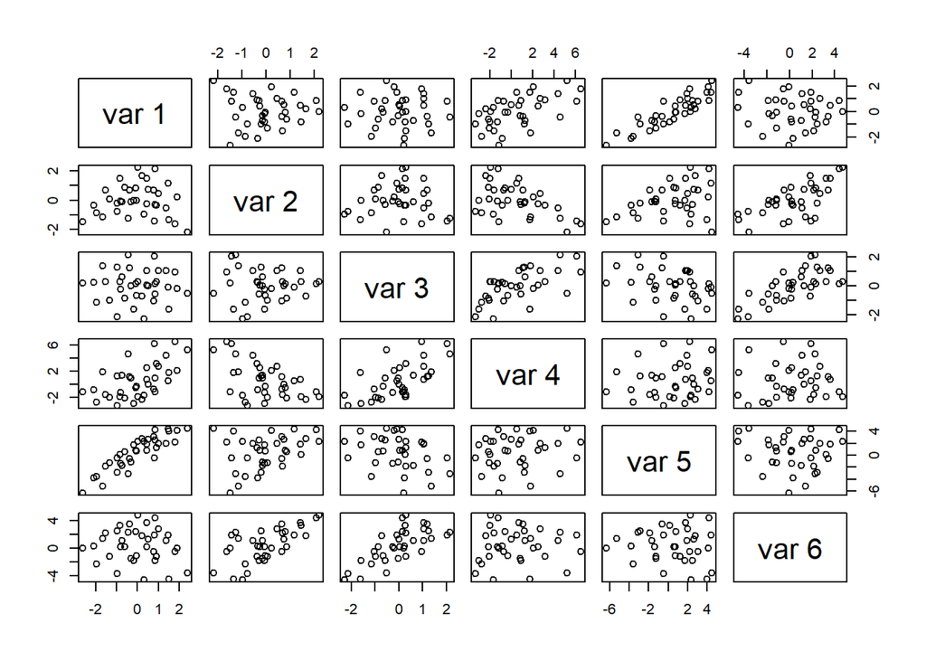

```r
pairs(cbind(out$points[,1:3], out.iso$points[,1:3]))
```

```r
round( cor(cbind(out$points[,1:3], out.iso$points[,1:3])), 2)
```

```
##       [,1]  [,2]  [,3]  [,4]  [,5]  [,6]
## [1,]  1.00  0.00  0.00  0.57  0.89 -0.10
## [2,]  0.00  1.00  0.00 -0.51  0.33  0.65
## [3,]  0.00  0.00  1.00  0.62 -0.31  0.72
## [4,]  0.57 -0.51  0.62  1.00  0.14  0.04
## [5,]  0.89  0.33 -0.31  0.14  1.00 -0.08
## [6,] -0.10  0.65  0.72  0.04 -0.08  1.00
```